# AIML_ML_Project_Full_Code_Notebook_SUBMIT

## Problem Statement

### Context

AllLife Bank is a mid-sized, fast-growing US-based financial institution that offers a range of retail banking services, including savings and checking accounts, fixed deposits, and personal loans. The bank’s business model is centered on building long-term customer relationships, expanding its retail footprint, and growing its loan portfolio to drive sustainable profitability through interest income.

It currently relies on a large base of liability customers (depositors) but faces a significant under-representation of asset customers (borrowers). To drive profitability through interest income, the bank must aggressively expand its loan portfolio by converting existing depositors into personal loan customers.

Last year’s pilot campaign achieved a 9% conversion rate, validating the potential of this strategy. However, to optimize marketing spend and improve efficiency, the retail marketing department requires a more data-driven approach. Enhancing the success ratio of these campaigns is critical for sustainable growth and maximizing customer lifetime value.

### Objective

The objective is to develop a predictive classification model that identifies patterns and key factors driving personal loan adoption among existing liability customers. By uncovering the demographic and behavioral drivers of loan conversion, the goal is to enable targeted segmentation and more precise marketing interventions that improve campaign conversion rates, optimize marketing spend, and enhance overall profitability through higher-quality loan portfolio growth.

### Data Dictionary

- `ID`: Customer ID
- `Age`: Customer’s age in completed years
- `Experience`: #years of professional experience
- `Income`: Annual income of the customer (in thousand dollars)
- `ZIP Code`: Home Address ZIP code.
- `Family`: the Family size of the customer
- `CCAvg`: Average spending on credit cards per month (in thousand dollars)
- `Education`: Education Level. 1: Undergrad; 2: Graduate;3: Advanced/Professional
- `Mortgage`: Value of house mortgage if any. (in thousand dollars)
- `Personal_Loan`: Did this customer accept the personal loan offered in the last campaign? (0: No, 1: Yes)
- `Securities_Account`: Does the customer have securities account with the bank? (0: No, 1: Yes)
- `CD_Account`: Does the customer have a certificate of deposit (CD) account with the bank? (0: No, 1: Yes)
- `Online`: Do customers use internet banking facilities? (0: No, 1: Yes)
- `CreditCard`: Does the customer use a credit card issued by any other Bank (excluding All life Bank)? (0: No, 1: Yes)

## Importing necessary libraries

```python
# Installing the libraries with the specified version.
import subprocess
import sys

subprocess.check_call([sys.executable, "-m", "pip", "install", "--break-system-packages", "numpy", "pandas", "matplotlib", "seaborn", "scikit-learn", "-q"])
```

```
0
```

**Note**:

1. After running the above cell, kindly restart the notebook kernel (for Jupyter Notebook) or runtime (for Google Colab), write the relevant code for the project from the next cell, and run all cells sequentially from the next cell.
2. On executing the above line of code, you might see a warning regarding package dependencies. This error message can be ignored as the above code ensures that all necessary libraries and their dependencies are maintained to successfully execute the code in this notebook.

```python
import pandas as pd
import numpy as np
import matplotlib.pyplot as plt
import seaborn as sns
from sklearn.tree import DecisionTreeClassifier, plot_tree
from sklearn.model_selection import train_test_split
from sklearn.metrics import confusion_matrix, classification_report, accuracy_score, precision_score, recall_score, f1_score, roc_auc_score, roc_curve
import warnings
warnings.filterwarnings("ignore")
print("All libraries imported successfully!")
```

```
All libraries imported successfully!
```

## Loading the dataset

```python
Loan = pd.read_csv("Loan_Modelling.csv")
data = Loan.copy()
print(f"Dataset loaded: {data.shape}")
```

```
Dataset loaded: (5000, 14)
```

## Data Overview

- Observations: Check shape, types, statistics
- Sanity checks: Missing values, duplicates

```python
print("First 5 rows:")
print(data.head())
print("\nLast 5 rows:")
print(data.tail())
print(f"\nShape: {data.shape}")
print(f"\nData Types:\n{data.dtypes}")
print(f"\nMissing Values:\n{data.isnull().sum()}")
print(f"\nDuplicates: {data.duplicated().sum()}")
```

```
First 5 rows:
   ID  Age  Experience  Income  ZIPCode  Family  CCAvg  Education  Mortgage  \
0   1   25           1      49    91107       4    1.6          1         0
1   2   45          19      34    90089       3    1.5          1         0
2   3   39          15      11    94720       1    1.0          1         0
3   4   35           9     100    94112       1    2.7          2         0
4   5   35           8      45    91330       4    1.0          2         0

   Personal_Loan  Securities_Account  CD_Account  Online  CreditCard
0              0                   1           0       0           0
1              0                   1           0       0           0
2              0                   0           0       0           0
3              0                   0           0       0           0
4              0                   0           0       0           1

Last 5 rows:
        ID  Age  Experience  Income  ZIPCode  Family  CCAvg  Education  \
4995  4996   29           3      40    92697       1    1.9          3
4996  4997   30           4      15    92037       4    0.4          1
4997  4998   63          39      24    93023       2    0.3          3
4998  4999   65          40      49    90034       3    0.5          2
4999  5000   28           4      83    92612       3    0.8          1

      Mortgage  Personal_Loan  Securities_Account  CD_Account  Online  \
4995         0              0                   0           0       1
4996        85              0                   0           0       1
4997         0              0                   0           0       0
4998         0              0                   0           0       1
4999         0              0                   0           0       1

      CreditCard
4995           0
4996           0
4997           0
4998           0
4999           1

Shape: (5000, 14)

Data Types:
```

[output cut: 19 more lines]

```
Experience            0
Income                0
ZIPCode               0
Family                0
CCAvg                 0
Education             0
Mortgage              0
Personal_Loan         0
Securities_Account    0
CD_Account            0
Online                0
CreditCard            0
dtype: int64

Duplicates: 0
```

## Exploratory Data Analysis.

EDA is a critical step in any data project used to investigate and understand the data before model construction.

The following questions serve as a starting point to help you approach the analysis and generate initial insights:

**Questions**:

1. What is the distribution of mortgage attribute? Are there any noticeable patterns or outliers in the distribution?
2. How many customers have credit cards?
3. What are the attributes that have a strong correlation with the target attribute (personal loan)?
4. How does a customer's interest in purchasing a loan vary with their education?
5. How does a customer's interest in purchasing a loan vary with their age?

**[IMPORTANT]** Beyond the Basics: Please note that these are guiding questions only. To receive full points for this rubric section, you are expected to perform a thorough analysis that goes beyond these specific questions to uncover deeper trends and relationships within the data.

### Question 1: Mortgage Distribution

```
============================================================
Q1: MORTGAGE DISTRIBUTION ANALYSIS
============================================================

Mortgage Statistics:
  Mean: $56.50K
  Median: $0.00K
  Min: $0.00K
  Max: $635.00K
  Zeros: 3462 (69.2%)
  Outliers: 291
```

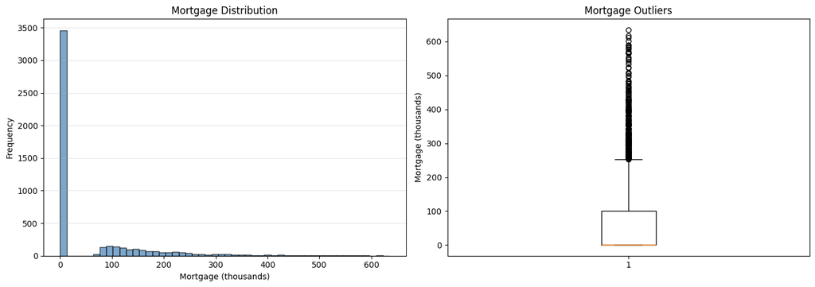

```
✓ Insight: Right-skewed, many zeros (renters), legitimate outliers (high properties)
```

```python
print("="*60)
print("Q1: MORTGAGE DISTRIBUTION ANALYSIS")
print("="*60)
print(f"\nMortgage Statistics:")
print(f"  Mean: ${data['Mortgage'].mean():.2f}K")
print(f"  Median: ${data['Mortgage'].median():.2f}K")
print(f"  Min: ${data['Mortgage'].min():.2f}K")
print(f"  Max: ${data['Mortgage'].max():.2f}K")
print(f"  Zeros: {(data['Mortgage']==0).sum()} ({(data['Mortgage']==0).sum()/len(data)*100:.1f}%)")

Q1 = data['Mortgage'].quantile(0.25)
Q3 = data['Mortgage'].quantile(0.75)
IQR = Q3 - Q1
outliers = len(data[data['Mortgage'] > Q3 + 1.5*IQR])
print(f"  Outliers: {outliers}")

fig, axes = plt.subplots(1, 2, figsize=(14, 5))
axes[0].hist(data['Mortgage'], bins=50, color='steelblue', edgecolor='black', alpha=0.7)
axes[0].set_title('Mortgage Distribution')
axes[0].set_xlabel('Mortgage (thousands)')
axes[0].set_ylabel('Frequency')
axes[0].grid(axis='y', alpha=0.3)

axes[1].boxplot(data['Mortgage'])
axes[1].set_ylabel('Mortgage (thousands)')
axes[1].set_title('Mortgage Outliers')
plt.tight_layout()
plt.show()

print("✓ Insight: Right-skewed, many zeros (renters), legitimate outliers (high properties)")
```

### Question 2: Credit Card Ownership

```
============================================================
Q2: CREDIT CARD OWNERSHIP
============================================================

No Credit Card: 3530 (70.6%)
Yes Credit Card: 1470 (29.4%)
```

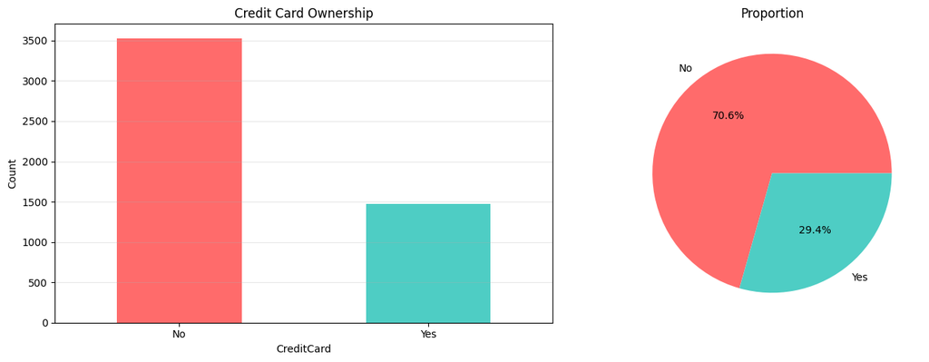

```
✓ Insight: 29.4% have credit from other banks (engagement signal)
```

```python
print("\n" + "="*60)
print("Q2: CREDIT CARD OWNERSHIP")
print("="*60)
cc = data['CreditCard'].value_counts()
cc_pct = data['CreditCard'].value_counts(normalize=True) * 100
print(f"\nNo Credit Card: {cc[0]} ({cc_pct[0]:.1f}%)")
print(f"Yes Credit Card: {cc[1]} ({cc_pct[1]:.1f}%)")

fig, axes = plt.subplots(1, 2, figsize=(14, 5))
cc.plot(kind='bar', ax=axes[0], color=['#FF6B6B', '#4ECDC4'])
axes[0].set_title('Credit Card Ownership')
axes[0].set_xticklabels(['No', 'Yes'], rotation=0)
axes[0].set_ylabel('Count')
axes[0].grid(axis='y', alpha=0.3)

axes[1].pie(cc, labels=['No', 'Yes'], autopct='%1.1f%%', colors=['#FF6B6B', '#4ECDC4'])
axes[1].set_title('Proportion')
plt.tight_layout()
plt.show()

print(f"✓ Insight: {cc_pct[1]:.1f}% have credit from other banks (engagement signal)")
```

### Question 3: Correlation with Personal Loan

```
============================================================
Q3: CORRELATION WITH TARGET
============================================================

Correlation with Personal_Loan:
Personal_Loan         1.000000
Income                0.502462
CCAvg                 0.366889
CD_Account            0.316355
Mortgage              0.142095
Education             0.136722
Family                0.061367
Securities_Account    0.021954
Online                0.006278
CreditCard            0.002802
ZIPCode              -0.002974
Experience           -0.007413
Age                  -0.007726
ID                   -0.024801
Name: Personal_Loan, dtype: float64
```

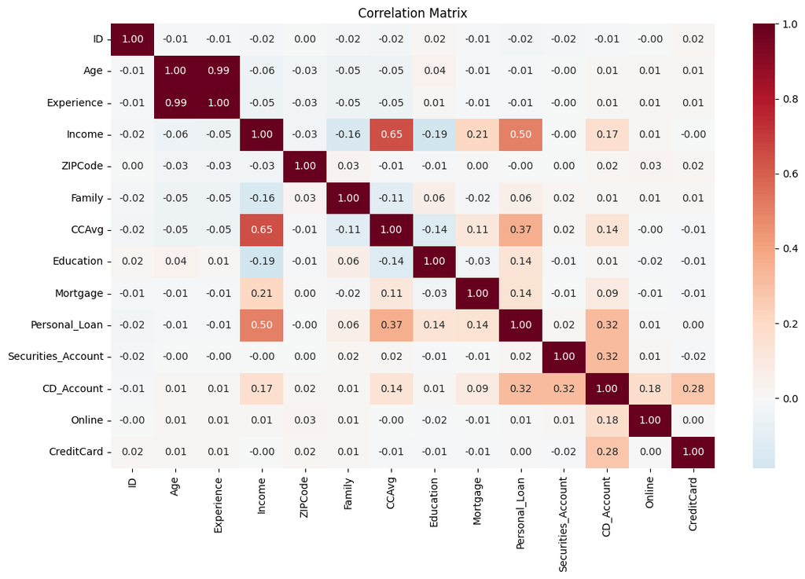

```
✓ Insight: Income is STRONGEST predictor
```

```python
print("\n" + "="*60)
print("Q3: CORRELATION WITH TARGET")
print("="*60)
corr = data.corr()['Personal_Loan'].sort_values(ascending=False)
print("\nCorrelation with Personal_Loan:")
print(corr)

plt.figure(figsize=(12, 8))
sns.heatmap(data.corr(), annot=True, fmt='.2f', cmap='RdBu_r', center=0)
plt.title('Correlation Matrix')
plt.tight_layout()
plt.show()

print("✓ Insight: Income is STRONGEST predictor")
```

### Question 4: Education vs Loan Acceptance

```
============================================================
Q4: EDUCATION VS LOAN ACCEPTANCE
============================================================

Acceptance by Education:
           count  rate_%
Edu_Label
Advanced    1501   13.66
Graduate    1403   12.97
Undergrad   2096    4.44
```

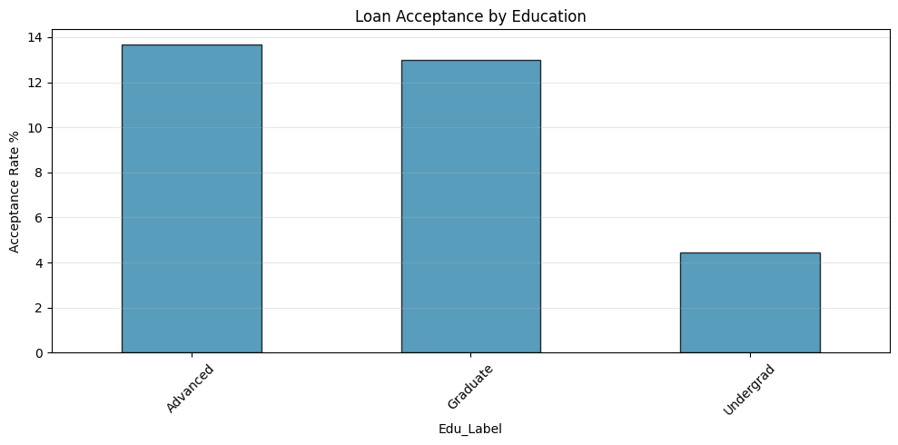

```
✓ Insight: Higher education = Higher acceptance
```

```python
print("\n" + "="*60)
print("Q4: EDUCATION VS LOAN ACCEPTANCE")
print("="*60)

edu_map = {1: 'Undergrad', 2: 'Graduate', 3: 'Advanced'}
data['Edu_Label'] = data['Education'].map(edu_map)

edu_loan = data.groupby('Edu_Label')['Personal_Loan'].agg(['count', 'sum', 'mean'])
edu_loan['rate_%'] = (edu_loan['mean'] * 100).round(2)
print("\nAcceptance by Education:")
print(edu_loan[['count', 'rate_%']])

fig, ax = plt.subplots(figsize=(10, 5))
edu_loan['rate_%'].plot(kind='bar', ax=ax, color='#2E86AB', edgecolor='black', alpha=0.8)
ax.set_title('Loan Acceptance by Education')
ax.set_ylabel('Acceptance Rate %')
ax.set_xticklabels(ax.get_xticklabels(), rotation=45)
ax.grid(axis='y', alpha=0.3)
plt.tight_layout()
plt.show()

print("✓ Insight: Higher education = Higher acceptance")
```